# Heart disease mortality rate prediction

#### DT w/ Adaptive Boosting

Adaboost reweights the training set in iterations to include more of those observations that were misclassified in the previous iteration so the model can "learn from its mistakes".

```python
#Decision Tree train model. Call up my model and name it clf
from sklearn.ensemble import AdaBoostClassifier

# Create and fit an AdaBoosted decision tree
clf_dt = AdaBoostClassifier(DecisionTreeClassifier(class_weight='balanced', criterion='gini', max_depth=5,
            max_features=None, max_leaf_nodes=None,
            min_impurity_decrease=0.0, min_impurity_split=None,
            min_samples_leaf=1, min_samples_split=2,
            min_weight_fraction_leaf=0.0, presort=False, random_state=35,
            splitter='best'),algorithm="SAMME",n_estimators=200)

#Call up the model to see the parameters you can tune (and their default setting)
#print(clf_dt)
#Fit clf to the training data
clf_dt = clf_dt.fit(features_train, target_train)
#Predict clf DT model again test data
target_predicted_dt = clf_dt.predict(features_test)

predicted=target_predicted_dt
expected = target_test

false_positive_rate, true_positive_rate, thresholds = roc_curve(expected, predicted)
print("AUC:" ,auc(false_positive_rate, true_positive_rate))
print("DT Accuracy Score", accuracy_score(target_test, target_predicted_dt))
print(classification_report(target_test, target_predicted_dt))
print(confusion_matrix(target_test, target_predicted_dt))
```

```
AUC: 0.8966315734543985
DT Accuracy Score 0.896875
             precision    recall  f1-score   support

        0.0       0.90      0.90      0.90       501
        1.0       0.89      0.89      0.89       459

avg / total       0.90      0.90      0.90       960

[[452  49]
 [ 50 409]]
```

#### cross-validate decision tree

```python
#verify DT with Cross Validation
scores = cross_val_score(clf_dt, features_train, target_train, cv=10)
print("Cross Validation Score for each K",scores)
scores.mean()
```

```
Cross Validation Score for each K [0.89777778 0.88444444 0.86222222 0.89285714 0.89732143 0.9103139
 0.87892377 0.87443946 0.9058296  0.9103139 ]
```

```
0.8914443643675707
```

#### ROC Curve of Decision Tree

The ROC Curve shows the tradeoff between capturing all of the true positive and recieving more false positive predictions.

```
ROC AUC: 0.897
```

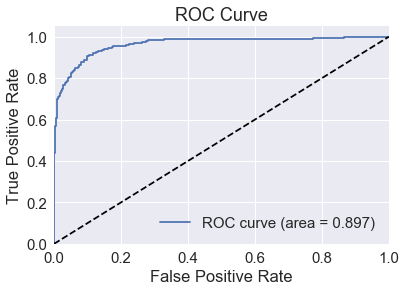

```python
# Determine the false positive and true positive rates
fpr, tpr, _ = roc_curve(target_test, clf_dt.predict_proba(features_test)[:,1])

# Calculate the AUC
roc_auc = auc(false_positive_rate, true_positive_rate)
print('ROC AUC: %0.3f' % roc_auc)

# Plot of a ROC curve for a specific class
plt.figure()
plt.plot(fpr, tpr, label='ROC curve (area = %0.3f)' % roc_auc)
plt.plot([0, 1], [0, 1], 'k--')
plt.xlim([0.0, 1.0])
plt.ylim([0.0, 1.05])
plt.xlabel('False Positive Rate')
plt.ylabel('True Positive Rate')
plt.title('ROC Curve')
plt.legend(loc="lower right")
plt.show()
```

#### Decision Tree Performance:

The model performance was boosted signinifantly from the baseline (defaults w/ max depth=3) accuracy of 76.7% and captured 67% of the true positives.

After using grid search the model (which changed max depth to 5, used balanced classes, and used the gini index). The models performance was boosted marginally (Accuracy to 79.8% and True positive recall of 82%)and the true positive recall precsion actually dropped (from 81% to 77%).

A Bagging classifier is an ensemble meta-estimator that fits base classifiers each on random subsets of the original dataset and then aggregate their individual predictions (either by voting or by averaging) to form a final prediction. This reduces the variance by introducing randomization into its construction procedure and then making an ensemble out of it.

I then used bagging, fits base classifiers each on random subsets of the original dataset and then aggregate their individual predictions (either by voting or by averaging) to form a final prediction. This reduces the variance by introducing randomization into its construction procedure and then making an ensemble out of it. This improved performance of the model to an accuracy of 82.4% while capturing 82% of the True Positives.

I then added adaptive boosting, which reweights the training set in iterations to include more of those observations that were misclassified in the previous iteration so the model can "learn from its mistakes". This significantly boosted performance of the model to an accuracy of 89.6% while capturing 89% of the True Positives. As seen in the chart (above) it also had an AUC of 0.897, which explains the relationship of True Positives to False Positives. I then used cross validated to find a mean of .891, which is close to that of the model (.896). The range of accuracies is also within an expected range (from .862-.910), this gives us some confidence that the model is not overfitting.

## Random Forest

```python
## import random forest
from sklearn.ensemble import RandomForestClassifier

rf = RandomForestClassifier(random_state=35)
#print(rf)
rf.fit(features_train, target_train)
# test random forest model
target_predicted_rf = rf.predict(features_test)

predicted=target_predicted_rf
expected = target_test

false_positive_rate, true_positive_rate, thresholds = roc_curve(expected, predicted)
print("AUC:" ,auc(false_positive_rate, true_positive_rate))
print("Random Forest Accuracy", accuracy_score(target_test, target_predicted_rf))
target_names = ["Below Avg", "Above Avg"]
print(classification_report(target_test, target_predicted_rf, target_names=target_names))
print(confusion_matrix(target_test, target_predicted_rf))
```

```
AUC: 0.8545131958305611
Random Forest Accuracy 0.85625
             precision    recall  f1-score   support

  Below Avg       0.84      0.89      0.87       501
  Above Avg       0.88      0.81      0.84       459

avg / total       0.86      0.86      0.86       960

[[448  53]
 [ 85 374]]
```

```python
##
from sklearn.ensemble import RandomForestClassifier

rf = AdaBoostClassifier(RandomForestClassifier(random_state=35)
                            ,algorithm="SAMME",n_estimators=200)

rf = RandomForestClassifier(random_state=35)
#print(rf)
rf.fit(features_train, target_train)
# test random forest model
target_predicted_rf = rf.predict(features_test)

predicted=target_predicted_rf
expected = target_test

false_positive_rate, true_positive_rate, thresholds = roc_curve(expected, predicted)
print("AUC:" ,auc(false_positive_rate, true_positive_rate))
print("Random Forest Accuracy", accuracy_score(target_test, target_predicted_rf))
target_names = ["Below Avg", "Above Avg"]
print(classification_report(target_test, target_predicted_rf, target_names=target_names))
print(confusion_matrix(target_test, target_predicted_rf))
```

```
AUC: 0.8545131958305611
Random Forest Accuracy 0.85625
             precision    recall  f1-score   support

  Below Avg       0.84      0.89      0.87       501
  Above Avg       0.88      0.81      0.84       459

avg / total       0.86      0.86      0.86       960

[[448  53]
 [ 85 374]]
```

#### use GridSearch

```python
start_time = time.clock()

## set parameters
parameters = {'class_weight':["balanced",'balanced_subsample', None], 'max_features' : ["auto", "log2"], 'criterion':["entropy", "gini"], 'n_estimators' : [5, 10, 20, 50, 100]}
rf = RandomForestClassifier(random_state=35)
grid_rf = GridSearchCV(rf, parameters,n_jobs=-1, cv=10)
grid_rf.fit(features_train, target_train)


false_positive_rate, true_positive_rate, thresholds = roc_curve(expected, predicted)
print("AUC:" ,auc(false_positive_rate, true_positive_rate))
#print("SCORES", grid_knn.cv_results_)
print("BEST Estm",grid_rf.best_estimator_)
print("BEST SCORE",grid_rf.best_score_)
print("BEST PARAM",grid_rf.best_params_)

print("Time to run", time.clock() - start_time, "minutes")
```

[output not shown]

#### Optimal Random Forest Parameters:

The gridsearch model choose to not weight classes. It also set the max number of features at log2 when looking for the best split. The 'n_estimators' which represents number of trees in the forest moved from the default 10 to 50.

```python
#Decision Tree train model. Call up my model and name it clf
from sklearn import tree

rf = RandomForestClassifier(bootstrap=True, class_weight=None, criterion='gini',
            max_depth=None, max_features='log2', max_leaf_nodes=None,
            min_impurity_decrease=0.0, min_impurity_split=None,
            min_samples_leaf=1, min_samples_split=2,
            min_weight_fraction_leaf=0.0, n_estimators=50, n_jobs=1,
            oob_score=False, random_state=35, verbose=0, warm_start=False)
#Call up the model to see the parameters you can tune (and their default setting)
print(rf)
#Fit clf to the training data
rf_dt = rf.fit(features_train, target_train)
#Predict rf model again test data
target_predicted_dt = rf_dt.predict(features_test)

predicted=target_predicted_rf
expected = target_test

false_positive_rate, true_positive_rate, thresholds = roc_curve(expected, predicted)
print("AUC:" ,auc(false_positive_rate, true_positive_rate))
print("DT Accuracy Score", accuracy_score(target_test, target_predicted_dt))
print(classification_report(target_test, target_predicted_dt))
print(confusion_matrix(target_test, target_predicted_dt))
```

```
RandomForestClassifier(bootstrap=True, class_weight=None, criterion='gini',
            max_depth=None, max_features='log2', max_leaf_nodes=None,
            min_impurity_decrease=0.0, min_impurity_split=None,
            min_samples_leaf=1, min_samples_split=2,
            min_weight_fraction_leaf=0.0, n_estimators=50, n_jobs=1,
            oob_score=False, random_state=35, verbose=0, warm_start=False)
AUC: 0.8545131958305611
DT Accuracy Score 0.871875
             precision    recall  f1-score   support

        0.0       0.87      0.89      0.88       501
        1.0       0.88      0.85      0.86       459

avg / total       0.87      0.87      0.87       960

[[446  55]
 [ 68 391]]
```

#### cross-validate decision tree

```python
#verify DT with Cross Validation
scores = cross_val_score(rf_dt, features_train, target_train, cv=10)
print("Cross Validation Score for each K",scores)
scores.mean()
```

```
Cross Validation Score for each K [0.88444444 0.87555556 0.86666667 0.84821429 0.90625    0.87892377
 0.87892377 0.85650224 0.87892377 0.87892377]
```

```
0.8753328261797992
```

#### ROC Curve of Random Forest

```
ROC AUC: 0.855
```

[figure not shown]

```python
# Determine the false positive and true positive rates
false_positive_rate, true_positive_rate, thresholds = roc_curve(expected, predicted)

# Calculate the AUC
roc_auc = auc(false_positive_rate, true_positive_rate)
print('ROC AUC: %0.3f' % roc_auc)

# Plot of a ROC curve for a specific class
plt.figure()
plt.plot(fpr, tpr, label='ROC curve (area = %0.3f)' % roc_auc)
plt.plot([0, 1], [0, 1], 'k--')
plt.xlim([0.0, 1.0])
plt.ylim([0.0, 1.05])
plt.xlabel('False Positive Rate')
plt.ylabel('True Positive Rate')
plt.title('ROC Curve')
plt.legend(loc="lower right")
plt.show()
```

#### Random Forest Performance:

The baseline had an accuracy of 85.6% and captured 81% of the true positives. This method uses bootstrapping (sampling with replacement) by default.

## Extremely Random Forest

```python
#Decision Tree train model. Call up my model and name it clf
from sklearn import tree
from sklearn.ensemble import ExtraTreesClassifier

rf = ExtraTreesClassifier(bootstrap=True, class_weight=None, criterion='gini',
            max_depth=None, max_features='log2', max_leaf_nodes=None,
            min_impurity_decrease=0.0, min_impurity_split=None,
            min_samples_leaf=1, min_samples_split=2,
            min_weight_fraction_leaf=0.0, n_estimators=50, n_jobs=1,
            oob_score=False, random_state=35, verbose=0, warm_start=False)
#Call up the model to see the parameters you can tune (and their default setting)
#print(rf)
#Fit clf to the training data
rf_dt = rf.fit(features_train, target_train)
#Predict rf model again test data
target_predicted_dt = rf_dt.predict(features_test)

predicted=target_predicted_dt
expected = target_test

false_positive_rate, true_positive_rate, thresholds = roc_curve(expected, predicted)
print("AUC:" ,auc(false_positive_rate, true_positive_rate))

print("DT Accuracy Score", accuracy_score(target_test, target_predicted_dt))
print(classification_report(target_test, target_predicted_dt))
print(confusion_matrix(target_test, target_predicted_dt))
```

```
AUC: 0.8932722789714689
DT Accuracy Score 0.89375
             precision    recall  f1-score   support

        0.0       0.89      0.90      0.90       501
        1.0       0.89      0.88      0.89       459

avg / total       0.89      0.89      0.89       960

[[453  48]
 [ 54 405]]
```

#### ROC Curve of Extremely Random Forest

The ROC Curve shows the tradeoff between capturing all of the true positive and recieving more false positive predictions.

```
ROC AUC: 0.893
```

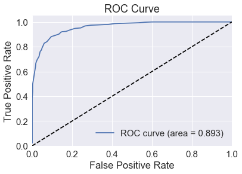

```python
# Determine the false positive and true positive rates
fpr, tpr, _ = roc_curve(target_test, rf_dt.predict_proba(features_test)[:,1])

# Calculate the AUC
roc_auc = auc(false_positive_rate, true_positive_rate)
print('ROC AUC: %0.3f' % roc_auc)

# Plot of a ROC curve for a specific class
plt.figure()
plt.plot(fpr, tpr, label='ROC curve (area = %0.3f)' % roc_auc)
plt.plot([0, 1], [0, 1], 'k--')
plt.xlim([0.0, 1.0])
plt.ylim([0.0, 1.05])
plt.xlabel('False Positive Rate')
plt.ylabel('True Positive Rate')
plt.title('ROC Curve')
plt.legend(loc="lower right")
plt.show()
```

#### Extremely Random Forest Performance:

In extremely randomized trees (see ExtraTreesClassifier and ExtraTreesRegressor classes), randomness goes one step further in the way splits are computed. As in random forests, a random subset of candidate features is used, but instead of looking for the most discriminative thresholds, thresholds are drawn at random for each candidate feature and the best of these randomly-generated thresholds is picked as the splitting rule. This usually allows to reduce the variance of the model a bit more, at the expense of a slightly greater increase in bias.

## SVM Linear

```python
start_time = time.clock()
from sklearn.svm import SVC
#standard linear SVC
clf_lin = SVC(kernel='linear', C=1.0,class_weight='balanced',gamma='auto')
clf_lin.fit(features_train, target_train)

predicted= clf_lin.predict(features_test)
expected = target_test

false_positive_rate, true_positive_rate, thresholds = roc_curve(expected, predicted)
print("AUC:" ,auc(false_positive_rate, true_positive_rate))
# summarize the fit of the model
print(classification_report(expected, predicted_SVM,target_names=['No', 'Yes']))
print(confusion_matrix(expected, predicted_SVM))
print(accuracy_score(expected,predicted_SVM))
print("Time to run", time.clock() - start_time, "seconds")
```

```
AUC: 0.8259363625689797
             precision    recall  f1-score   support

         No       0.85      0.83      0.84       501
        Yes       0.82      0.84      0.83       459

avg / total       0.83      0.83      0.83       960

[[414  87]
 [ 74 385]]
0.8322916666666667
Time to run 0.1993009999999913 seconds
```

### SVM (w/ grid search and cv)

```python
start_time = time.clock()
from sklearn.svm import SVC
parameters = {'C':[.01,.05,1,3,4,9,10], 'class_weight':['balanced'],'gamma': [1, 10, 100, 'auto']}
svr = SVC(kernel='linear')
grid_svm = GridSearchCV(svr, parameters,n_jobs=-1, cv=5)
grid_svm.fit(features_train, target_train)
#print("SCORES", grid_svm.cv_results_)
print("BEST SCORE", grid_svm.best_score_)
print("BEST PARAM", grid_svm.best_params_)
print("Time to run", time.clock() - start_time, "seconds")
```

```
BEST SCORE 0.8471849865951743
BEST PARAM {'C': 9, 'class_weight': 'balanced', 'gamma': 1}
Time to run 0.48778799999999833 seconds
```

```python
#standard linear SVC
clf_lin = SVC(kernel='linear', C=9,class_weight='balanced',gamma=1)
clf_lin.fit(features_train, target_train)
predicted_SVM=clf_lin.predict(features_test)
expected = target_test

# summarize the fit of the model
false_positive_rate, true_positive_rate, thresholds = roc_curve(expected, predicted)
print("AUC:" ,auc(false_positive_rate, true_positive_rate))

print(classification_report(expected, predicted_SVM,target_names=['No', 'Yes']))
print(confusion_matrix(expected, predicted_SVM))
print(accuracy_score(expected,predicted_SVM))
print("Time to run", time.clock() - start_time, "seconds")
```

```
AUC: 0.8259363625689797
             precision    recall  f1-score   support

         No       0.85      0.83      0.84       501
        Yes       0.82      0.84      0.83       459

avg / total       0.83      0.83      0.83       960

[[414  87]
 [ 74 385]]
0.8322916666666667
Time to run 0.45234199999998737 seconds
```

#### ROC Curve of SVM (Linear)

The ROC Curve shows the tradeoff between capturing all of the true positive and recieving more false positive predictions.

```
ROC AUC: 0.826
```

[figure not shown]

```python
# Determine the false positive and true positive rates
false_positive_rate, true_positive_rate, thresholds = roc_curve(expected, predicted)

# Calculate the AUC
roc_auc = auc(false_positive_rate, true_positive_rate)
print('ROC AUC: %0.3f' % roc_auc)

# Plot of a ROC curve for a specific class
plt.figure()
plt.plot(fpr, tpr, label='ROC curve (area = %0.3f)' % roc_auc)
plt.plot([0, 1], [0, 1], 'k--')
plt.xlim([0.0, 1.0])
plt.ylim([0.0, 1.05])
plt.xlabel('False Positive Rate')
plt.ylabel('True Positive Rate')
plt.title('ROC Curve')
plt.legend(loc="lower right")
plt.show()
```

#### Cross Validate Model (cv=10)

```python
#verify DT with Cross Validation
scores = cross_val_score(clf_lin, features_train, target_train, cv=10)
print("Cross Validation Score for each K",scores)
scores.mean()
```

```
Cross Validation Score for each K [0.87111111 0.84444444 0.82222222 0.81696429 0.85714286 0.84304933
 0.83856502 0.82959641 0.87443946 0.89237668]
```

```
0.8489911826464518
```

## SVM RBF

```python
start_time = time.clock()
from sklearn.svm import SVC
#standard linear SVC
clf_lin = SVC(kernel='rbf', C=1.0,class_weight='balanced',gamma='auto')
clf_lin.fit(features_train, target_train)

predicted_SVM=clf_lin.predict(features_test)
expected = target_test

# summarize the fit of the model
false_positive_rate, true_positive_rate, thresholds = roc_curve(expected, predicted)
print("AUC:" ,auc(false_positive_rate, true_positive_rate))

print(classification_report(expected, predicted_SVM,target_names=['No', 'Yes']))
print(confusion_matrix(expected, predicted_SVM))
print(accuracy_score(expected,predicted_SVM))
print("Time to run", time.clock() - start_time, "seconds")
```

```
AUC: 0.8259363625689797
             precision    recall  f1-score   support

         No       0.82      0.83      0.82       501
        Yes       0.81      0.81      0.81       459

avg / total       0.82      0.82      0.82       960

[[414  87]
 [ 89 370]]
0.8166666666666667
Time to run 0.34055000000000746 seconds
```

### SVM (w/ grid search and cv)

```python
start_time = time.clock()
from sklearn.svm import SVC
parameters = {'C':[.01,.05,1,3,4,9,10], 'class_weight':['balanced'],'gamma': [1, 10, 100, 'auto']}
svr = SVC(kernel='rbf')
grid_svm = GridSearchCV(svr, parameters,n_jobs=-1, cv=5)
grid_svm.fit(features_train, target_train)
#print("SCORES", grid_svm.cv_results_)
print("BEST SCORE", grid_svm.best_score_)
print("BEST PARAM", grid_svm.best_params_)
print("Time to run", time.clock() - start_time, "seconds")
```

```
BEST SCORE 0.8891867739052726
BEST PARAM {'C': 10, 'class_weight': 'balanced', 'gamma': 1}
Time to run 0.541172999999997 seconds
```

```python
#standard linear SVC
clf_lin = SVC(kernel='rbf', C=9,class_weight='balanced',gamma=1)
clf_lin.fit(features_train, target_train)

predicted=clf_lin.predict(features_test)
expected = target_test

# summarize the fit of the model
false_positive_rate, true_positive_rate, thresholds = roc_curve(expected, predicted)
print("AUC:" ,auc(false_positive_rate, true_positive_rate))

print(classification_report(expected, predicted_SVM,target_names=['No', 'Yes']))
print(confusion_matrix(expected, predicted_SVM))
print(accuracy_score(expected,predicted_SVM))
print("Time to run", time.clock() - start_time, "seconds")
```

```
AUC: 0.9232189216338564
             precision    recall  f1-score   support

         No       0.92      0.94      0.93       501
        Yes       0.93      0.91      0.92       459

avg / total       0.92      0.92      0.92       960

[[471  30]
 [ 43 416]]
0.9239583333333333
Time to run 0.9665149999999869 seconds
```

#### Cross Validate Model (cv=10)

```python
#verify DT with Cross Validation
scores = cross_val_score(clf_lin, features_train, target_train, cv=10)
print("Cross Validation Score for each K",scores)
scores.mean()
```

```
Cross Validation Score for each K [0.90222222 0.87555556 0.87111111 0.89732143 0.90178571 0.9103139
 0.89686099 0.89686099 0.89237668 0.9058296 ]
```

```
0.8950238184212399
```

#### ROC Curve of SVM (RBF)

The ROC Curve shows the tradeoff between capturing all of the true positive and recieving more false positive predictions.

```
ROC AUC: 0.923
```

[figure not shown]

```python
# Determine the false positive and true positive rates
false_positive_rate, true_positive_rate, thresholds = roc_curve(expected, predicted)

roc_auc = auc(false_positive_rate, true_positive_rate)
# Calculate the AUC

print('ROC AUC: %0.3f' % roc_auc)

# Plot of a ROC curve for a specific class
plt.figure()
plt.plot(fpr, tpr, label='ROC curve (area = %0.3f)' % roc_auc)
plt.plot([0, 1], [0, 1], 'k--')
plt.xlim([0.0, 1.0])
plt.ylim([0.0, 1.05])
plt.xlabel('False Positive Rate')
plt.ylabel('True Positive Rate')
plt.title('ROC Curve')
plt.legend(loc="lower right")
plt.show()
```

#### SVM (rbf) Performance:

The baseline had an accuracy of 81.6% and captured 81% of the true positives.

After using grid search the model (which changed C = 10, and gamma = 1). The models increased to an accuracy of 92.4% and True positive recall of 91%. Cross validation averaged 0.895 with a range of .871-.910, which a is below that of the model so we may expect this model to perform in this range when exposed to new data. As seen in the chart (above) it also had an AUC of 0.923, which explains the relationship of True Positives to False Positives.

## ANN

```python
from sklearn.neural_network import MLPClassifier
mlp = MLPClassifier(hidden_layer_sizes=(30,30,30))
print(mlp)
mlp.fit(features_train, target_train)
predictions = mlp.predict(features_test)
from sklearn.metrics import classification_report,confusion_matrix
print("Accuracy", accuracy_score(target_test,predictions))
print(classification_report(target_test,predictions))
print(confusion_matrix(target_test,predictions))
```

```
MLPClassifier(activation='relu', alpha=0.0001, batch_size='auto', beta_1=0.9,
       beta_2=0.999, early_stopping=False, epsilon=1e-08,
       hidden_layer_sizes=(30, 30, 30), learning_rate='constant',
       learning_rate_init=0.001, max_iter=200, momentum=0.9,
       nesterovs_momentum=True, power_t=0.5, random_state=None,
       shuffle=True, solver='adam', tol=0.0001, validation_fraction=0.1,
       verbose=False, warm_start=False)
Accuracy 0.8510416666666667
             precision    recall  f1-score   support

        0.0       0.87      0.84      0.86       501
        1.0       0.83      0.86      0.85       459

avg / total       0.85      0.85      0.85       960

[[423  78]
 [ 65 394]]
```

```python
clf_NN1 =MLPClassifier(activation='relu', alpha=1e-05, batch_size='auto',
       beta_1=0.9, beta_2=0.999, early_stopping=False,
       epsilon=1e-08, hidden_layer_sizes=(50,50), learning_rate='constant',
       learning_rate_init=0.001, max_iter=10000, momentum=0.9,
       nesterovs_momentum=True, power_t=0.5, random_state=1, shuffle=True,
       solver='lbfgs', tol=0.0001, validation_fraction=0.1, verbose=False,
       warm_start=False)
clf_NN1.fit(features_train, target_train)
# test ANN
predicted=clf_NN1.predict(features_test)
expected = target_test

# summarize the fit of the model
false_positive_rate, true_positive_rate, thresholds = roc_curve(expected, predicted)
print("AUC:" ,auc(false_positive_rate, true_positive_rate))
print("Accuracy", accuracy_score(target_test, target_predicted_NN1))
target_names = ["Churn = no", "Churn = yes"]
print(classification_report(target_test, target_predicted_NN1, target_names=target_names))
print(confusion_matrix(target_test, target_predicted_NN1))
```

```
AUC: 0.8865602129075183
Accuracy 0.8864583333333333
             precision    recall  f1-score   support

 Churn = no       0.90      0.88      0.89       501
Churn = yes       0.88      0.89      0.88       459

avg / total       0.89      0.89      0.89       960

[[443  58]
 [ 51 408]]
```

#### ROC Curve of ANN

```
ROC AUC: 0.887
```

[figure not shown]

```python
# Determine the false positive and true positive rates
false_positive_rate, true_positive_rate, thresholds = roc_curve(expected, predicted)

# Calculate the AUC
roc_auc = auc(false_positive_rate, true_positive_rate)
print('ROC AUC: %0.3f' % roc_auc)

# Plot of a ROC curve for a specific class
plt.figure()
plt.plot(fpr, tpr, label='ROC curve (area = %0.3f)' % roc_auc)
plt.plot([0, 1], [0, 1], 'k--')
plt.xlim([0.0, 1.0])
plt.ylim([0.0, 1.05])
plt.xlabel('False Positive Rate')
plt.ylabel('True Positive Rate')
plt.title('ROC Curve')
plt.legend(loc="lower right")
plt.show()
```

#### ANN (classification) performance:

The second model had just 2 layers with 50 nodes each. It's alpha coefficient was also reduced and max iterations increased to 10,000 (from 200). This models accuracy increased to an 88.6% and True positive recall of 89%. As seen in the chart (above) it also had an AUC of 0.887, which explains the relationship of True Positives to False Positives.

# Regression Models

These model can be used to predict the heart disease rates for a county on a continuous scale and used in combination with classifiaction models to give hospital systems in new counties a better idea of what the prevelance of heart disease is more closely.

### Create Test/Train Split of data (for regression)

```python
# split dataset into testing and training (70/30)
features_train_reg, features_test_reg, target_train_reg, target_test_reg = train_test_split(
    c_reg.iloc[:,1:].values, c_reg.iloc[:,0].values, test_size=0.30, random_state=0)
```

```python
print(features_test_reg.shape)
print(features_train_reg.shape)
print(target_test_reg.shape)
print(target_train_reg.shape)
```

```
(960, 55)
(2238, 55)
(960,)
(2238,)
```

```python
# split dataset into testing and training (70/30)
features_train_reg, features_test_reg, target_train_reg, target_test_reg = train_test_split(
    c_reg.iloc[:,1:].values, c_reg.iloc[:,0].values, test_size=0.30, random_state=0)
```

## ANN for Regression

```python
print(features_test_reg.shape)
print(features_train_reg.shape)
print(target_test_reg.shape)
print(target_train_reg.shape)
```

```
(960, 55)
(2238, 55)
(960,)
(2238,)
```

```python
from sklearn.neural_network import MLPRegressor
mlp_reg = MLPRegressor(activation='relu', alpha=1e-05, batch_size='auto',
       beta_1=0.9, beta_2=0.999, early_stopping=False,
       epsilon=1e-08, hidden_layer_sizes=(50,50,50), learning_rate='constant',
       learning_rate_init=0.001, max_iter=10000, momentum=0.9,
       nesterovs_momentum=True, power_t=0.5, random_state=1, shuffle=True,
       solver='lbfgs', tol=0.0001, validation_fraction=0.1, verbose=False,
       warm_start=False)
print(mlp_reg)
mlp_reg.fit(features_train_reg, target_train_reg)
predictions = mlp_reg.predict(features_test_reg)

# make predictions
expected = target_test_reg
predicted = mlp_reg.predict(features_test_reg)

# summarize the fit of the model
mse = np.mean((predicted-expected)**2)
print("mse" ,mse)
print("R-squared" ,mlp_reg.score(features_test_reg, target_test_reg))


# from sklearn.metrics import classification_report,confusion_matrix
# print("Accuracy", accuracy_score(target_test_reg,predictions))
# print(classification_report(target_test_reg,predictions))
# print(confusion_matrix(target_test_reg,predictions))
```

```
MLPRegressor(activation='relu', alpha=1e-05, batch_size='auto', beta_1=0.9,
       beta_2=0.999, early_stopping=False, epsilon=1e-08,
       hidden_layer_sizes=(50, 50, 50), learning_rate='constant',
       learning_rate_init=0.001, max_iter=10000, momentum=0.9,
       nesterovs_momentum=True, power_t=0.5, random_state=1, shuffle=True,
       solver='lbfgs', tol=0.0001, validation_fraction=0.1, verbose=False,
       warm_start=False)
mse 0.00659130982000532
R-squared 0.6829544533577203
```

#### ANN (regression) performance:

This model has 3 layers with 50 nodes each. It's max iterations increased to 10,000. This model. R^2, which represents the explained to total variance is 0.68. I will use this as my performance metric.

## Extremely Random Forest (for regression)

```python
#Decision Tree train model. Call up my model and name it clf
from sklearn import tree
from sklearn.ensemble import ExtraTreesRegressor

rf_reg = ExtraTreesRegressor(random_state=35)
#Call up the model to see the parameters you can tune (and their default setting)

print(rf_reg)
rf_reg.fit(features_train_reg, target_train_reg)
predictions = rf_reg.predict(features_test_reg)

# make predictions
expected = target_test_reg
predicted = rf_reg.predict(features_test_reg)

# summarize the fit of the model
mse = np.mean((predicted-expected)**2)
print("mse" ,mse)
print("R-squared" ,rf_reg.score(features_test_reg, target_test_reg))
```

```
ExtraTreesRegressor(bootstrap=False, criterion='mse', max_depth=None,
          max_features='auto', max_leaf_nodes=None,
          min_impurity_decrease=0.0, min_impurity_split=None,
          min_samples_leaf=1, min_samples_split=2,
          min_weight_fraction_leaf=0.0, n_estimators=10, n_jobs=1,
          oob_score=False, random_state=35, verbose=0, warm_start=False)
mse 0.005029059157743721
R-squared 0.7580995502708847
```

#### Extremely Random Forest (for regression) performance:

Using the default parameters, this model had a higher R^2 (0.758) than the ANN.

## Lasso Regression

```python
# Lasso Regression
# fit a LASSO model to the data
from sklearn.linear_model import Lasso
model = Lasso(alpha=0.001, random_state=33)
model.fit(features_train_reg, target_train_reg)
print(model)
# make predictions
expected = target_test_reg
predicted = model.predict(features_test_reg)
# summarize the fit of the model
mse = np.mean((predicted-expected)**2)
print("MSE:" ,mse)
print("R-squared:" ,model.score(features_test_reg, target_test_reg))
```

[output not shown]

#### Lasso w Grid search

```python
## create Grid Search to optimize tuning parameters
from sklearn.model_selection import train_test_split, cross_val_score, KFold, GridSearchCV
import time

# use a full grid over all parameters
param_grid = {"alpha": [.001, .1, 1, 10, 100]}
start_time = time.clock()

# run grid search
grid_search = GridSearchCV(model, param_grid=param_grid,n_jobs=-1)
grid_search.fit(features_train_reg, target_train_reg)


#print(grid_search.cv_results_)
#print("SCORES", grid_search.cv_results_)
print("BEST SCORE", grid_search.best_score_)
print("BEST PARAM", grid_search.best_params_)
print("Time to run", time.clock() - start_time, "seconds")
```

```
BEST SCORE 0.6320335159354977
BEST PARAM {'alpha': 0.001}
Time to run 0.1771619999999956 seconds
```

```python
## check out the coefficients

# #Show importance of each feature in Random Forest
# zip(df.columns[1:20], rf.feature_importances_)

print(list(zip(model.coef_, c_reg.columns[1:10])))
```

```
[(-0.03523359058220195, 'econ__pct_civilian_labor'), (0.0, 'econ__pct_unemployment'), (0.0, 'econ__pct_uninsured_adults'), (-0.0, 'econ__pct_uninsured_children'), (0.0, 'demo__pct_female'), (0.0, 'demo__pct_below_18_years_of_age'), (-0.15708742092458677, 'demo__pct_aged_65_years_and_older'), (-0.0, …
```

```python
## View resulting feature weights
import pandas as pd

table = list(zip(model.coef_, c_reg.columns))
df = pd.DataFrame(table)
df.sort_values([0], ascending=[False], inplace=True)

## keep only columns with absolute value > 0
df = df[(abs(df[0]) > 0)]
## view remaining features
print(c_reg.shape)
print(df.shape)
df
```

```
(3198, 56)
(23, 2)
```

|  | 0 | 1 |
| --- | --- | --- |
| 17 | 0.337 | demo__birth_rate_per_1k |
| 23 | 0.221 | health__pct_excessive_drinking |
| 20 | 0.146 | health__pct_adult_smoking |
| 12 | 0.144 | demo__pct_asian |
| 26 | 0.066 | health__homicides_per_100k |
| 18 | 0.049 | demo__death_rate_per_1k |
| 19 | 0.045 | health__pct_adult_obesity |
| 21 | 0.045 | health__pct_diabetes |
| 8 | 0.042 | demo__pct_hispanic |
| 13 | 0.040 | demo__pct_adults_less_than_a_high_school_diploma |
| 34 | 0.009 | Nonmetro - Completely rural or less than 2,500 urban population, not adjacent to a metro area |
| 40 | 0.008 | Micropolitan adjacent to a small metro area |
| 52 | 0.004 | Manufacturing-dependent |
| 53 | 0.002 | Mining-dependent |
| 41 | 0.002 | Micropolitan not adjacent to a metro area |
| 44 | 0.001 | Noncore adjacent to a small metro with town of at least 2,500 residents |
| 33 | -0.002 | Nonmetro - Completely rural or less than 2,500 urban population, adjacent to a metro area |
| 39 | -0.004 | Micropolitan adjacent to a large metro area |
| 54 | -0.016 | Nonspecialized |
| 47 | -0.018 | Noncore not adjacent to a metro/micro area and contains a town of 2,500 or more residents |
| 0 | -0.035 | heart_disease_mortality_per_100k |
| 49 | -0.042 | Small-in a metro area with fewer than 1 million residents |
| 6 | -0.157 | demo__pct_below_18_years_of_age |

#### LASSO performance:

Using the default parameters, this model had an R^2 of 0.635 which is below the other models but still a signinifant amount of the variance explained. The advantage of the LASSO model is interpretibility of the features. It reduced the number of features from 56 to 23 and the feature weights allow hospital to know how their county received it's prediction by the feature weight. This may also help them focus on patients/habits may be best to focus on (though the true underlying cause should be analyzed).

## Conclusion:

The best performing model across all 3 measures (Accuracy, TP recall, and AUC) was the SVM (rbf) using grid search the model (which changed C = 10, and gamma = 1). The models increased to an accuracy of 92.4% and True positive recall of 91%. Cross validation averaged 0.895 with a range of .871-.910, which a is below that of the model so we may expect this model to perform in this range when exposed to new data. As seen in the chart (above) it also had an AUC of 0.923, which explains the relationship of True Positives to False Positives.

Of the regression models, the Extremely Random Forest explained the most variance of any model with an R^2 of 0.758. However, I would reccomend the LASSO regression model for ease of interpretation. It cut the number of features in half (from 56 to 23) and still achieved an R^2 of 0.635. This may also help them focus on patients/habits may be best to focus on (though the true underlying cause should be analyzed).

#### code folding

```python
from IPython.display import HTML

def hide_input_cell(self=None):
    '''
    Hides a cell's input by double-clicking on (ln()).

    Required Parameter(s): None
    Optional Parameter(s): None
    '''
    return HTML('''<script type="text/Javascript">
                   $("<style type='text/css'> div.input.collapse { max-height:60px; overflow:scroll;} </style>").appendTo("head");
                   $('div.prompt.input_prompt').on('dblclick', function(event) {
                       console.log("CLICKED", arguments)
                       var c = $(event.target).closest('div.input')
                       if(c.hasClass('collapse')) {
                          c.removeClass('collapse');
                       } else {
                           c.addClass('collapse');
                       }
                     });
                   ''')
## call this function again in 1000ms
# setTimeout(click_cell, 1000)
```

```python
hide_input_cell()
```